# Casual Impact

The causal impact model lets us examine eCommerce and marketing time series data to understand whether changes have resulted in statistically significant performance improvement. Unlike other systems, Causal Impact predicts what would have happened based on a forecast made from the pre-treatment period and then compares what happened with what was forecast. This takes a time series data set including a treatment period and a post-treatment period and aims to identify whether it had a statistically significant impact on a chosen metric.

### Google Trends

To have an accurate prediction within the Casual Impact Model, we need other time series which are related to our outcome of interest but at the same time not affected by the campaign (treatment). We chose to retrieve Google Queries on fragrances e-commerce and other related keywords in our case. Google Trends returns data in daily granularity only if the time frame is less than nine months. But in our case, because the time frame is more than nine months, we’ll get weekly data and thanks to the below code, we can adjust it daily. Because Google Trends assess interest in relative values within the given period, it means that for a given keyword and month, Google Trend will estimate interest identically – with a local minimum of 0 and a local maximum of 100 – event in one month it had twice as many searches than in the other.

To get proper daily estimates, we did the following:

1- Query daily estimates for each month in the specified time frame;

2- Queries monthly data for the whole time frame;

3- Multiply daily estimates for each month from step 1 by its weight from step 2.

```r
library(gtrendsR)
library(tidyverse)
library(lubridate)
```

### Estimating Google trends of Sephora

```r
get_daily_gtrend <- function(keyword = c('sephora'), geo = 'IT', from = '2018-10-15', to = '2020-02-13') {
  if (ymd(to) >= floor_date(Sys.Date(), 'month')) {
    to <- floor_date(ymd(to), 'month') - days(1)

    if (to < from) {
      stop("Specifying \'to\' date in the current month is not allowed")
    }
  }

  aggregated_data <- gtrends(keyword = keyword, geo = geo, time = paste(from, to))
  if(is.null(aggregated_data$interest_over_time)) {
    print('There is no data in Google Trends!')
    return()
  }

  mult_m <- aggregated_data$interest_over_time %>%
    mutate(hits = as.integer(ifelse(hits == '<1', '0', hits))) %>%
    group_by(month = floor_date(date, 'month'), keyword) %>%
    summarise(hits = sum(hits)) %>%
    ungroup() %>%
    mutate(ym = format(month, '%Y-%m'),
           mult = hits / max(hits)) %>%
    select(month, ym, keyword, mult) %>%
    as_tibble()

  pm <- tibble(s = seq(ymd(from), ymd(to), by = 'month'),
               e = seq(ymd(from), ymd(to), by = 'month') + months(1) - days(1))

  raw_trends_m <- tibble()

  for (i in seq(1, nrow(pm), 1)) {
    curr <- gtrends(keyword, geo = geo, time = paste(pm$s[i], pm$e[i]))
    if(is.null(curr$interest_over_time)) next
    print(paste('for', pm$s[i], pm$e[i], 'retrieved', count(curr$interest_over_time), 'days of data (all keywords)'))
    raw_trends_m <- rbind(raw_trends_m,
                          curr$interest_over_time)
  }

  trend_m <- raw_trends_m %>%
    select(date, keyword, hits) %>%
    mutate(ym = format(date, '%Y-%m'),
           hits = as.integer(ifelse(hits == '<1', '0', hits))) %>%
    as_tibble()

  trend_res <- trend_m %>%
    left_join(mult_m) %>%
    mutate(sephora_hits = hits * mult) %>%
    select(date, keyword, sephora_hits) %>%
    as_tibble() %>%
    mutate(date = as.Date(date))

  return(trend_res)
}

G_daily_S<-get_daily_gtrend(keyword = c('sephora'), geo = 'IT', from = '2018-10-15', to = '2020-02-13')
```

```
[1] "for 2018-10-15 2018-11-14 retrieved 31 days of data (all keywords)"
[1] "for 2018-11-15 2018-12-14 retrieved 30 days of data (all keywords)"
[1] "for 2018-12-15 2019-01-14 retrieved 31 days of data (all keywords)"
[1] "for 2019-01-15 2019-02-14 retrieved 31 days of data (all keywords)"
[1] "for 2019-02-15 2019-03-14 retrieved 28 days of data (all keywords)"
[1] "for 2019-03-15 2019-04-14 retrieved 31 days of data (all keywords)"
[1] "for 2019-04-15 2019-05-14 retrieved 30 days of data (all keywords)"
[1] "for 2019-05-15 2019-06-14 retrieved 31 days of data (all keywords)"
[1] "for 2019-06-15 2019-07-14 retrieved 30 days of data (all keywords)"
[1] "for 2019-07-15 2019-08-14 retrieved 31 days of data (all keywords)"
[1] "for 2019-08-15 2019-09-14 retrieved 31 days of data (all keywords)"
[1] "for 2019-09-15 2019-10-14 retrieved 30 days of data (all keywords)"
[1] "for 2019-10-15 2019-11-14 retrieved 31 days of data (all keywords)"
[1] "for 2019-11-15 2019-12-14 retrieved 30 days of data (all keywords)"
[1] "for 2019-12-15 2020-01-14 retrieved 31 days of data (all keywords)"
[1] "for 2020-01-15 2020-02-14 retrieved 31 days of data (all keywords)"
```

### Estimating Google trends of Douglas

```r
get_daily_gtrend <- function(keyword = c('douglas'), geo = 'IT', from = '2018-10-15', to = '2020-02-13') {
  if (ymd(to) >= floor_date(Sys.Date(), 'month')) {
    to <- floor_date(ymd(to), 'month') - days(1)

    if (to < from) {
      stop("Specifying \'to\' date in the current month is not allowed")
    }
  }

  aggregated_data <- gtrends(keyword = keyword, geo = geo, time = paste(from, to))
  if(is.null(aggregated_data$interest_over_time)) {
    print('There is no data in Google Trends!')
    return()
  }

  mult_m <- aggregated_data$interest_over_time %>%
    mutate(hits = as.integer(ifelse(hits == '<1', '0', hits))) %>%
    group_by(month = floor_date(date, 'month'), keyword) %>%
    summarise(hits = sum(hits)) %>%
    ungroup() %>%
    mutate(ym = format(month, '%Y-%m'),
           mult = hits / max(hits)) %>%
    select(month, ym, keyword, mult) %>%
    as_tibble()

  pm <- tibble(s = seq(ymd(from), ymd(to), by = 'month'),
               e = seq(ymd(from), ymd(to), by = 'month') + months(1) - days(1))

  raw_trends_m <- tibble()

  for (i in seq(1, nrow(pm), 1)) {
    curr <- gtrends(keyword, geo = geo, time = paste(pm$s[i], pm$e[i]))
    if(is.null(curr$interest_over_time)) next
    print(paste('for', pm$s[i], pm$e[i], 'retrieved', count(curr$interest_over_time), 'days of data (all keywords)'))
    raw_trends_m <- rbind(raw_trends_m,
                          curr$interest_over_time)
  }

  trend_m <- raw_trends_m %>%
    select(date, keyword, hits) %>%
    mutate(ym = format(date, '%Y-%m'),
           hits = as.integer(ifelse(hits == '<1', '0', hits))) %>%
    as_tibble()

  trend_res <- trend_m %>%
    left_join(mult_m) %>%
    mutate(douglas_hits = hits * mult) %>%
    select(date, keyword, douglas_hits) %>%
    as_tibble() %>%
    mutate(date = as.Date(date))

  return(trend_res)
}

G_daily_D<-get_daily_gtrend(keyword = c('douglas'), geo = 'IT', from = '2018-10-15', to = '2020-02-13')
```

```
[1] "for 2018-10-15 2018-11-14 retrieved 31 days of data (all keywords)"
[1] "for 2018-11-15 2018-12-14 retrieved 30 days of data (all keywords)"
[1] "for 2018-12-15 2019-01-14 retrieved 31 days of data (all keywords)"
[1] "for 2019-01-15 2019-02-14 retrieved 31 days of data (all keywords)"
[1] "for 2019-02-15 2019-03-14 retrieved 28 days of data (all keywords)"
[1] "for 2019-03-15 2019-04-14 retrieved 31 days of data (all keywords)"
[1] "for 2019-04-15 2019-05-14 retrieved 30 days of data (all keywords)"
[1] "for 2019-05-15 2019-06-14 retrieved 31 days of data (all keywords)"
[1] "for 2019-06-15 2019-07-14 retrieved 30 days of data (all keywords)"
[1] "for 2019-07-15 2019-08-14 retrieved 31 days of data (all keywords)"
[1] "for 2019-08-15 2019-09-14 retrieved 31 days of data (all keywords)"
[1] "for 2019-09-15 2019-10-14 retrieved 30 days of data (all keywords)"
[1] "for 2019-10-15 2019-11-14 retrieved 31 days of data (all keywords)"
[1] "for 2019-11-15 2019-12-14 retrieved 30 days of data (all keywords)"
[1] "for 2019-12-15 2020-01-14 retrieved 31 days of data (all keywords)"
[1] "for 2020-01-15 2020-02-14 retrieved 31 days of data (all keywords)"
```

### Creating the data set

```r
#Combining Google Trends for both Sephora and Douglas
Gdaily_DS <- cbind(G_daily_D, G_daily_S)
Gdaily_DS<- Gdaily_DS[-488, ]
Gdaily_DS$keyword <- NULL
Gdaily_DS$keyword <- NULL

#Retrieve total sales and visits
df <- read.csv('/Users/carloardito/Deloitte/DeloitteR/Totals_R.csv', sep=",")
df$X <- NULL
df$tot_onpurc <- NULL

#Combining sales,visits with g trens from D and S
dfmaster <- cbind(df, Gdaily_DS)
dfmaster$date <- NULL
dfmaster$date <- NULL
dfmaster$keyword <- NULL
dfmaster$keyword <- NULL

#retrieve the Google query about the products
dfquery <- read.csv('/Users/carloardito/Deloitte/DeloitteR/dataset.csv', sep=",")
dfquery$day <- NULL
dfquery$convrate <- NULL
dfquery$avspend <- NULL
dfquery$visits <- NULL
dfquery$online_purchases <- NULL
```

### Casual Impact Algorithm

Once we have retrieved and transformed the Google queries, let us put together the Casual Impact algorithm.

The following model contains:

1- Sales

2- Visits

3- Google Trends of Sephora

4- Google Trends of Douglas

5- Google Queries of company Alpha

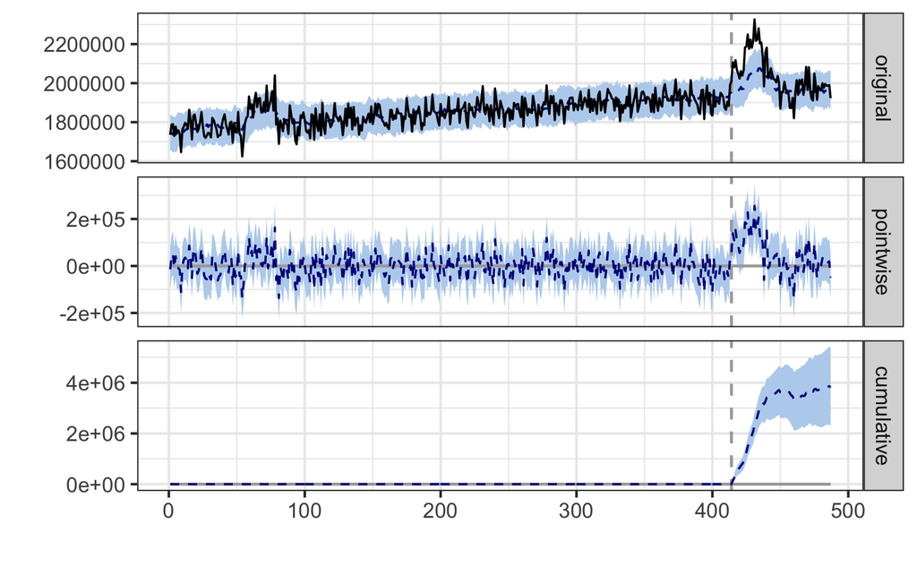

```r
#install.packages("CausalImpact")
df5 <- cbind(dfmaster, dfquery)
pre.period <- c(1,414) #fino a inizio campagna
post.period <- c(415,487)
dfmaster$day <- NULL

impact <- CausalImpact(df5, pre.period, post.period)
plot(impact)
```

```r
summary(impact, "report")
```

[output not shown]